# ROSA_vitaSPEC_fruits

# Calibration finale

[1] “eau”

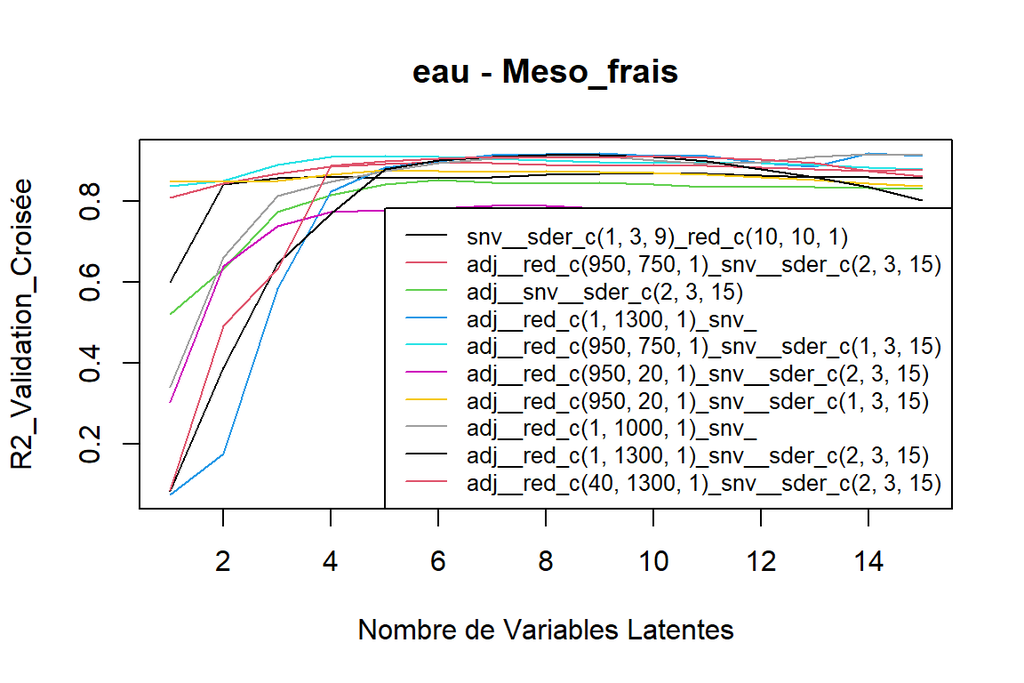

Pré : adj__red_c(1, 1300, 1)*snv*

R2 : 0.07 0.18 0.58 0.82 0.88 0.9 0.91 0.91 0.92 0.91 0.91 0.89 0.88 0.92 0.91

SEP : 9.32 8.79 6.24 4.08 3.33 3.1 2.84 2.82 2.79 2.88 2.9 3.24 3.43 2.79 2.88

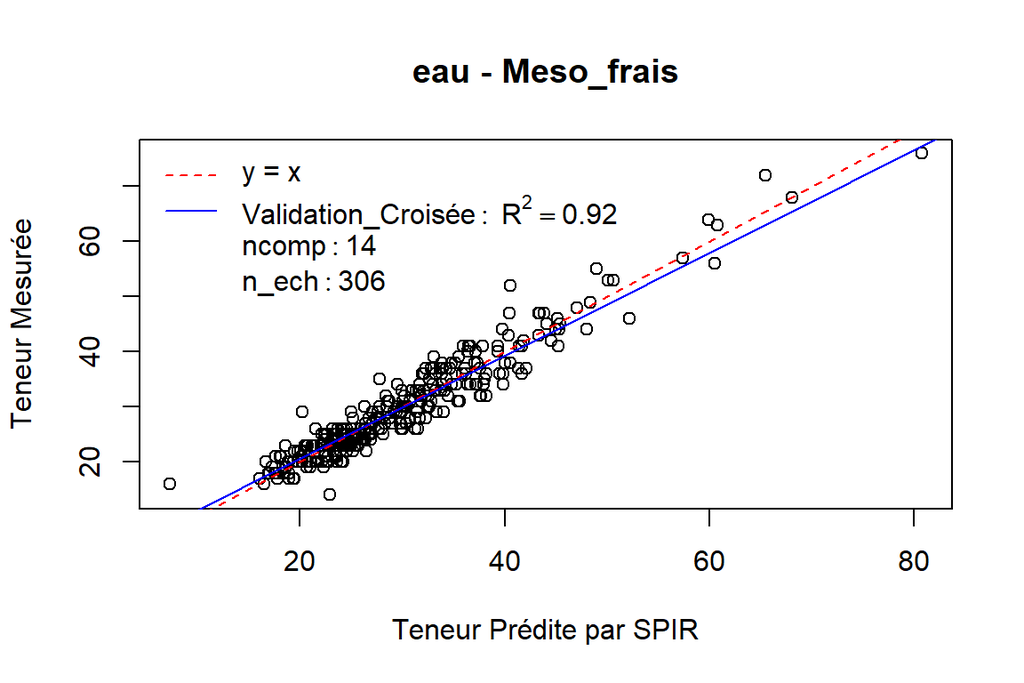

[1] “C14.0”

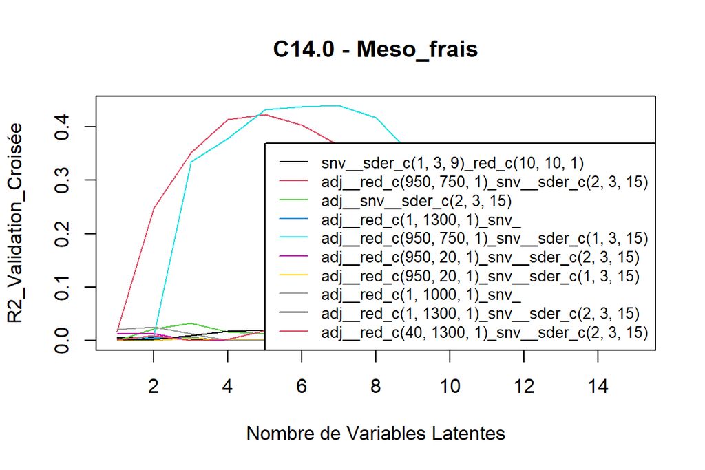

Pré : adj__red_c(950, 750, 1)_snv__sder_c(1, 3, 15)

R2 : 0 0.01 0.33 0.38 0.43 0.44 0.44 0.42 0.35 0.31 0.28 0.26 0.21 0.19 0.17

SEP : 0.36 0.38 0.29 0.28 0.27 0.27 0.27 0.28 0.31 0.33 0.35 0.36 0.41 0.42 0.44

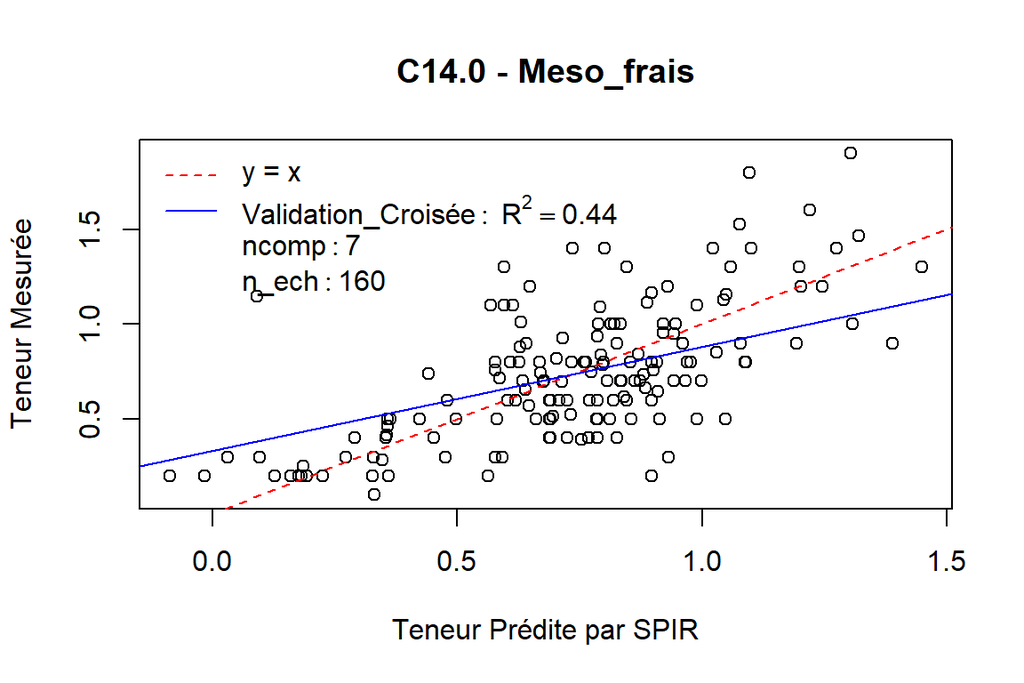

[1] “C16.0”

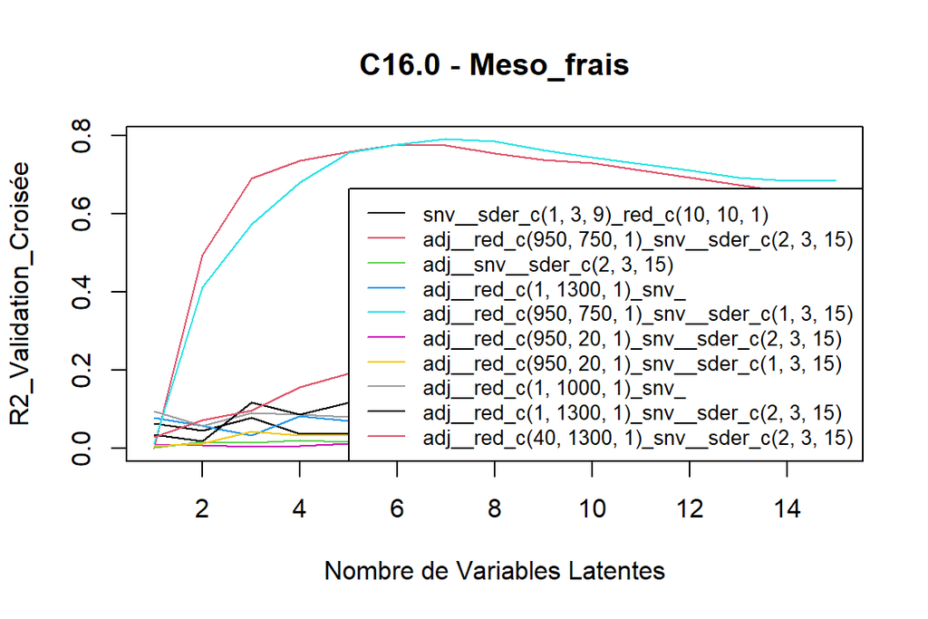

Pré : adj__red_c(950, 750, 1)_snv__sder_c(1, 3, 15)

R2 : 0.01 0.41 0.57 0.68 0.76 0.78 0.79 0.78 0.76 0.74 0.73 0.71 0.69 0.68 0.68

SEP : 5.15 3.98 3.38 2.93 2.56 2.45 2.37 2.41 2.55 2.67 2.8 2.91 3.02 3.08 3.11

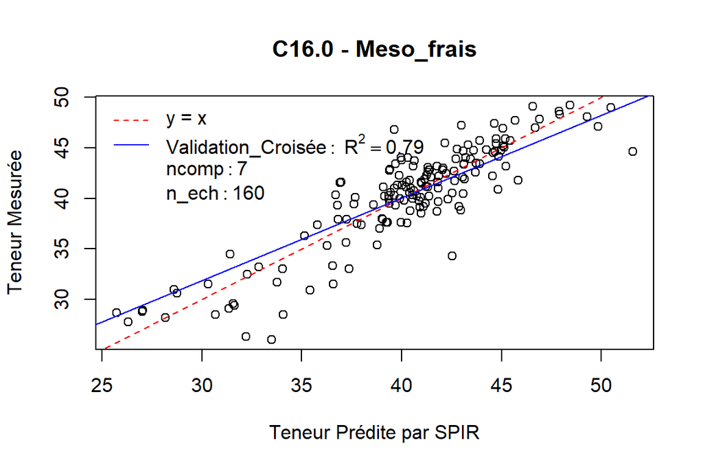

[1] “C18.0”

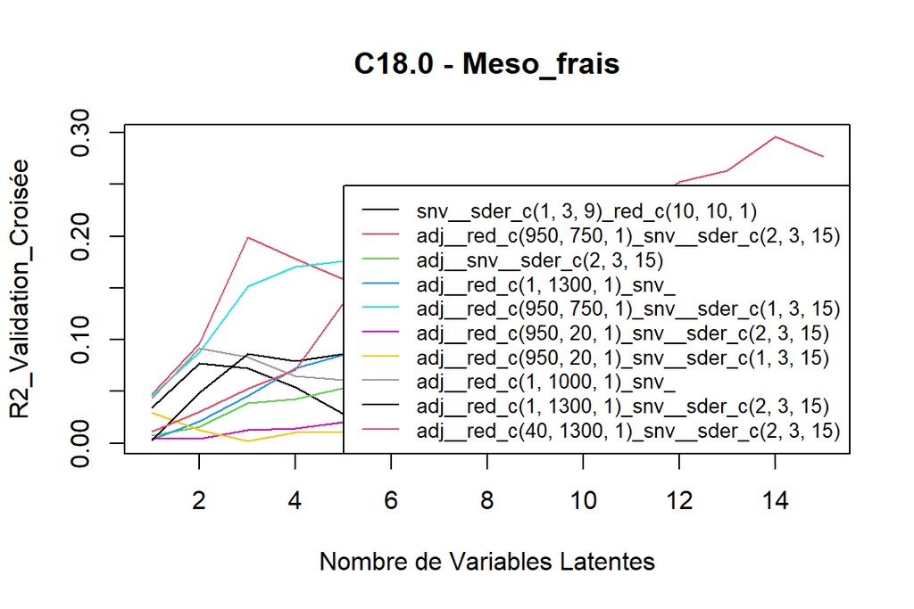

Pré : adj__red_c(40, 1300, 1)_snv__sder_c(2, 3, 15)

R2 : 0.01 0.03 0.05 0.07 0.14 0.13 0.13 0.19 0.22 0.21 0.22 0.25 0.26 0.3 0.28

SEP : 1.52 1.52 1.51 1.52 1.44 1.48 1.52 1.46 1.45 1.5 1.49 1.45 1.46 1.41 1.44

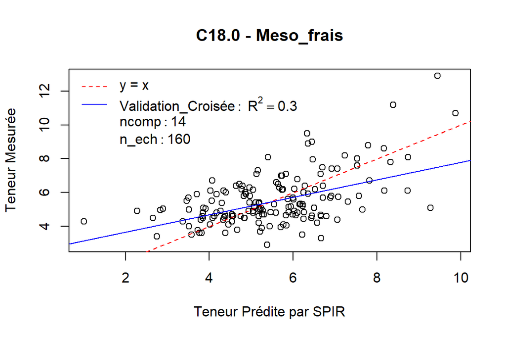

[1] “C18.1n9”

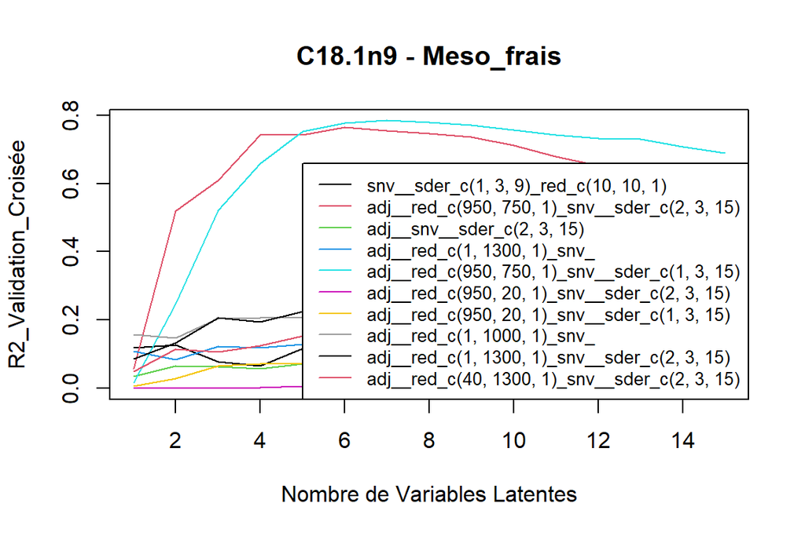

Pré : adj__red_c(950, 750, 1)_snv__sder_c(1, 3, 15)

R2 : 0.02 0.25 0.52 0.66 0.75 0.78 0.78 0.78 0.77 0.76 0.74 0.73 0.73 0.71 0.69

SEP : 5.44 4.81 3.8 3.21 2.74 2.6 2.57 2.61 2.69 2.84 2.95 3.06 3.08 3.29 3.45

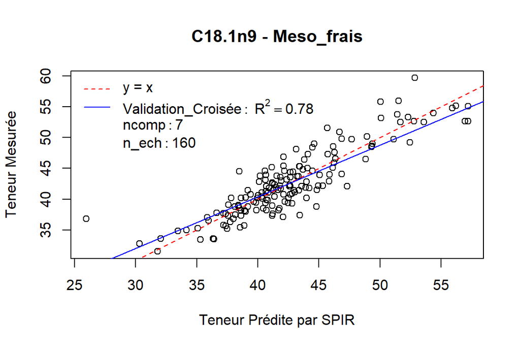

[1] “C18.1n7”

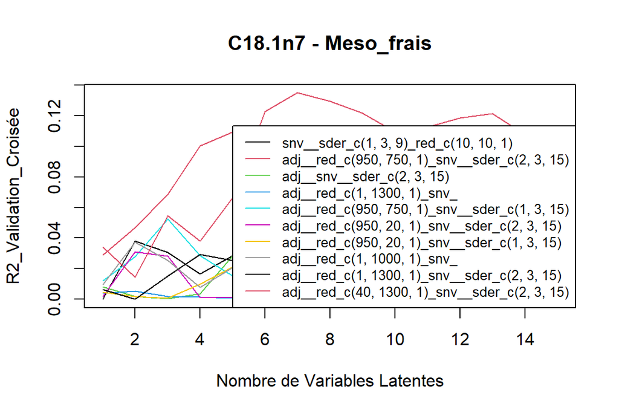

Pré : adj__red_c(40, 1300, 1)_snv__sder_c(2, 3, 15)

R2 : 0.03 0.01 0.05 0.04 0.07 0.12 0.13 0.13 0.12 0.11 0.11 0.12 0.12 0.11 0.11

SEP : 0.68 0.66 0.63 0.66 0.65 0.63 0.62 0.63 0.65 0.67 0.69 0.7 0.7 0.72 0.74

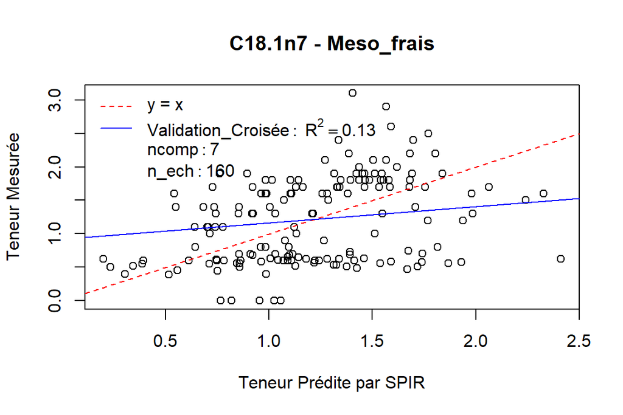

[1] “C18.2”

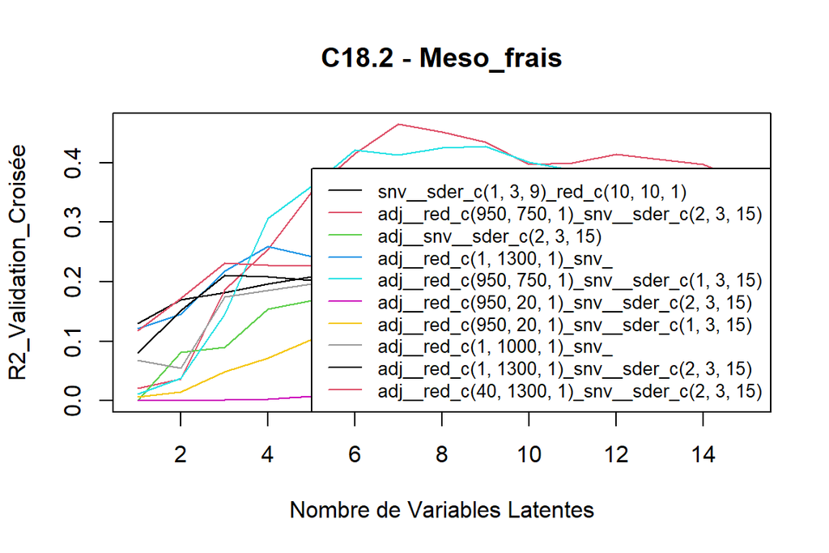

Pré : adj__red_c(950, 750, 1)_snv__sder_c(2, 3, 15)

R2 : 0.02 0.04 0.19 0.25 0.35 0.41 0.46 0.45 0.44 0.4 0.4 0.41 0.41 0.4 0.37

SEP : 1.64 1.64 1.5 1.46 1.37 1.31 1.25 1.29 1.33 1.44 1.45 1.45 1.51 1.56 1.66

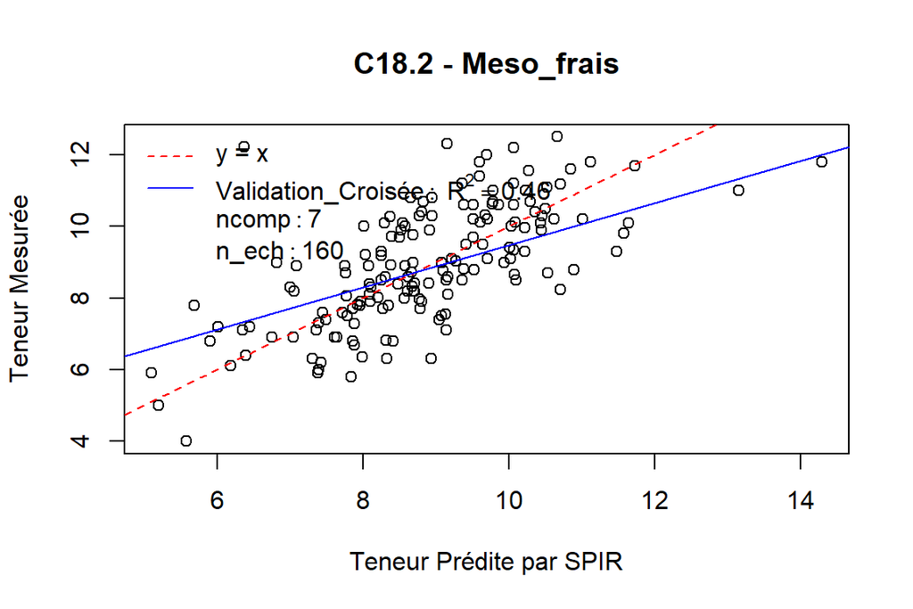

[1] “C18.3”

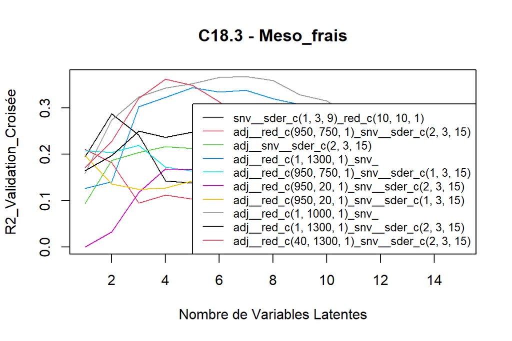

Pré : adj__red_c(1, 1000, 1)*snv*

R2 : 0.16 0.27 0.32 0.34 0.35 0.37 0.37 0.36 0.33 0.32 0.28 0.23 0.21 0.15 0.12

SEP : 0.11 0.1 0.1 0.1 0.09 0.09 0.09 0.09 0.1 0.1 0.1 0.11 0.11 0.12 0.12

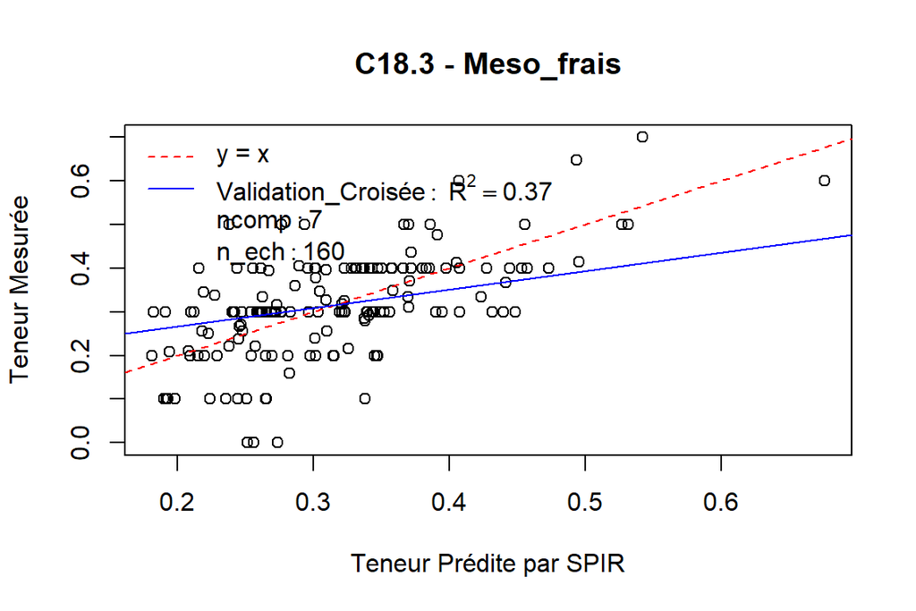

[1] “C20.0”

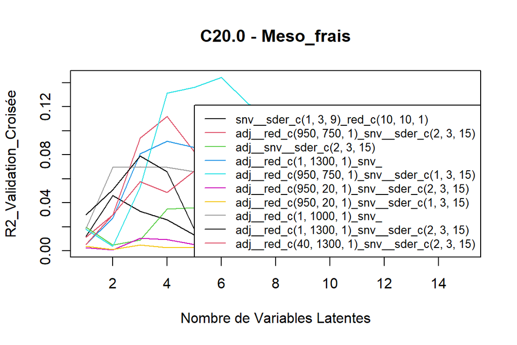

Pré : adj__red_c(950, 750, 1)_snv__sder_c(1, 3, 15)

R2 : 0.02 0 0.05 0.13 0.14 0.14 0.12 0.11 0.1 0.09 0.08 0.07 0.06 0.06 0.05

SEP : 0.11 0.11 0.11 0.1 0.1 0.1 0.11 0.11 0.11 0.12 0.13 0.14 0.15 0.16 0.16

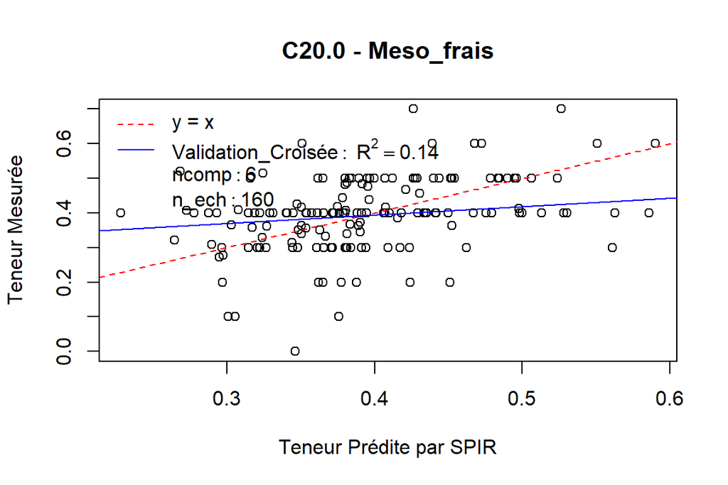

[1] “tlip.MS”

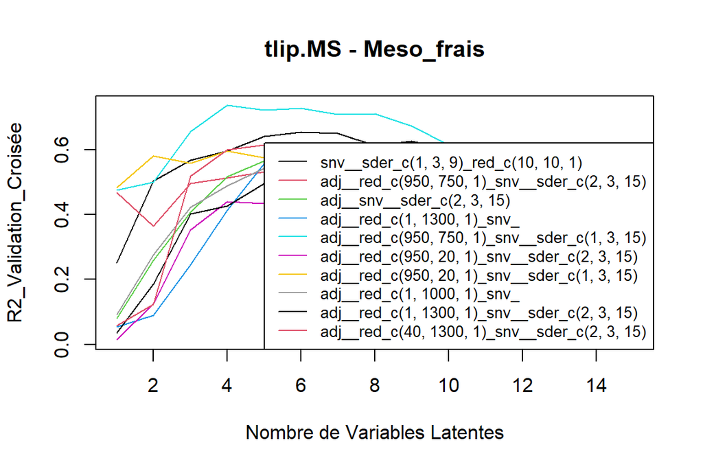

Pré : adj__red_c(950, 750, 1)_snv__sder_c(1, 3, 15)

R2 : 0.48 0.5 0.66 0.74 0.72 0.73 0.71 0.71 0.67 0.61 0.59 0.56 0.53 0.52 0.5

SEP : 3.43 3.35 2.78 2.44 2.53 2.52 2.61 2.58 2.75 3.08 3.24 3.45 3.58 3.68 3.8

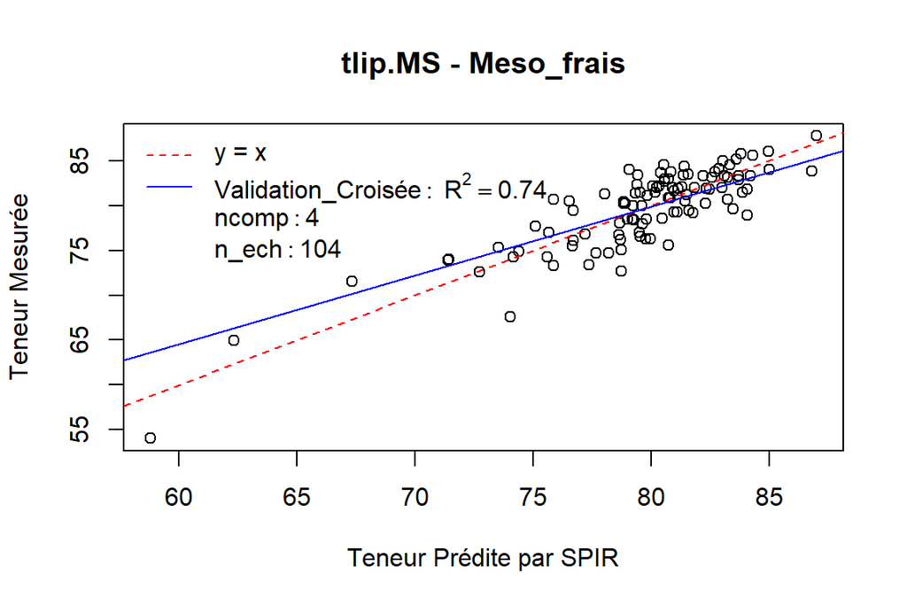

[1] “trans.alpha.carotne”

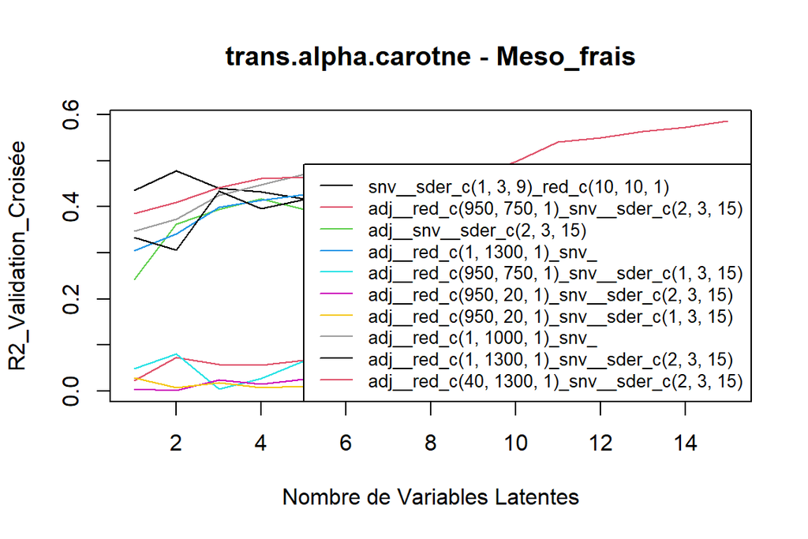

Pré : adj__red_c(40, 1300, 1)_snv__sder_c(2, 3, 15)

R2 : 0.39 0.41 0.44 0.46 0.46 0.47 0.47 0.47 0.46 0.5 0.54 0.55 0.56 0.57 0.59

SEP : 289.78 284.45 278.3 277.91 279.92 279.37 284.91 286.91 290.64 278.54 261.92 257.32 251.89 249.43 246.41

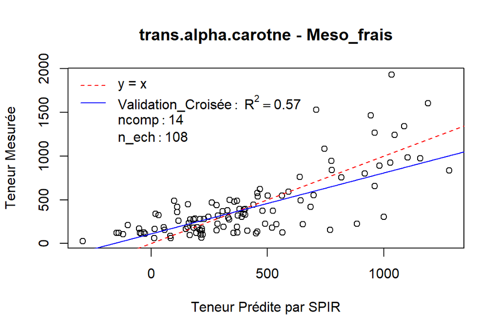

[1] “trans.beta.carotene”

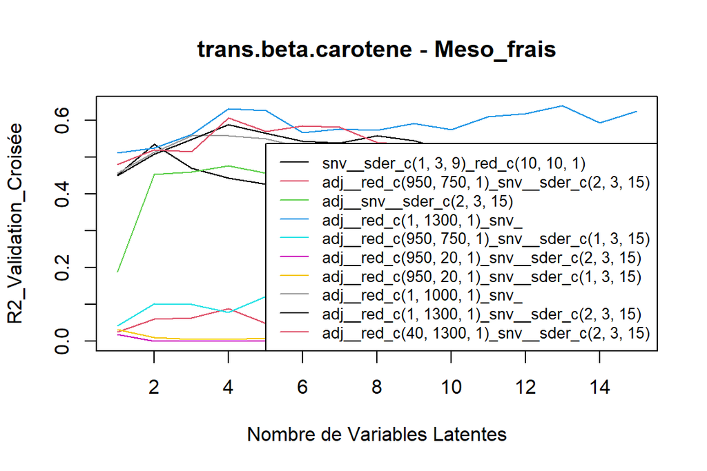

Pré : adj__red_c(1, 1300, 1)*snv*

R2 : 0.51 0.53 0.56 0.63 0.63 0.57 0.58 0.57 0.59 0.57 0.61 0.62 0.64 0.59 0.63

SEP : 247.06 243.92 233.97 214.85 216.33 234.42 232.25 233.96 229.07 237.61 224.08 220.75 213.75 234.96 223.45

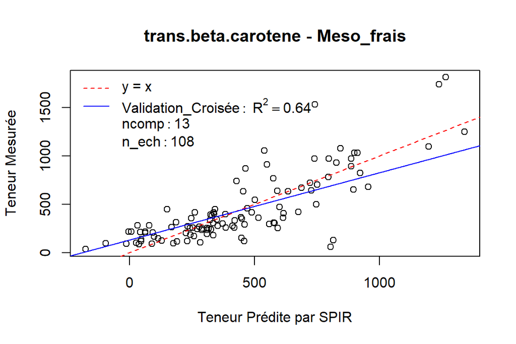

[1] “X13.cis.beta.carotene”

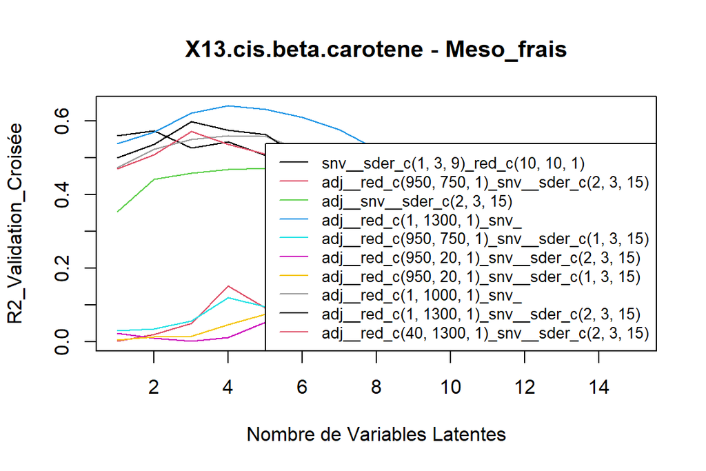

Pré : adj__red_c(1, 1300, 1)*snv*

R2 : 0.54 0.57 0.62 0.64 0.63 0.61 0.58 0.52 0.52 0.49 0.49 0.49 0.46 0.47 0.47

SEP : 24.76 24.12 22.5 21.9 22.24 22.92 24.06 26.06 26.91 27.92 28.4 28.3 29.42 29.32 29.37

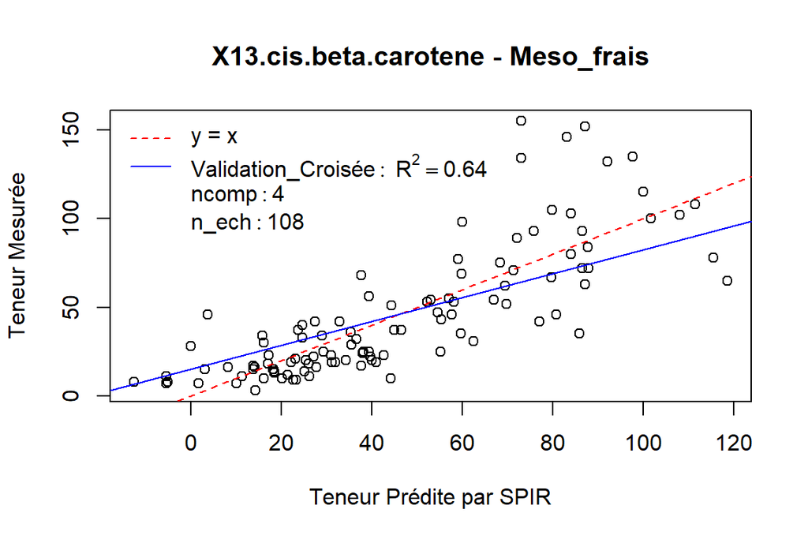

[1] “X9.cis.beta.carotene”

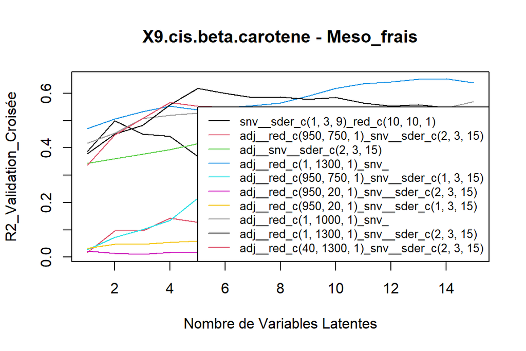

Pré : adj__red_c(1, 1300, 1)*snv*

R2 : 0.47 0.51 0.53 0.55 0.54 0.55 0.55 0.57 0.59 0.62 0.63 0.64 0.65 0.65 0.64

SEP : 52.56 50.84 49.46 48.43 49.42 49 48.54 48.12 46.61 45.18 44.63 43.61 43.22 43.27 44.81

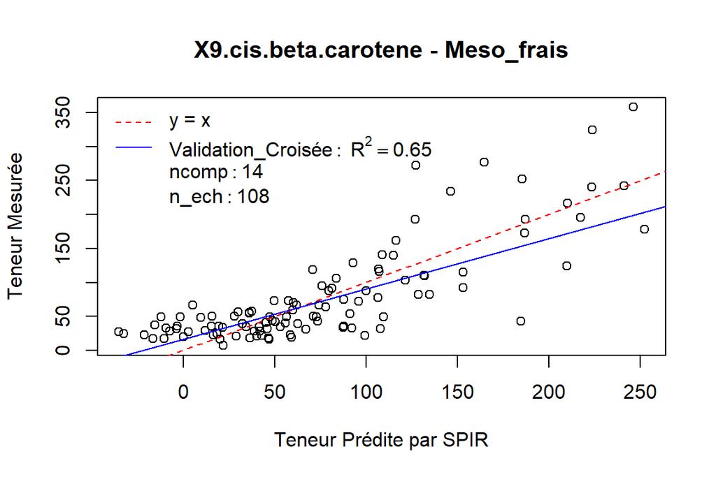

[1] “total.beta.carotenes”

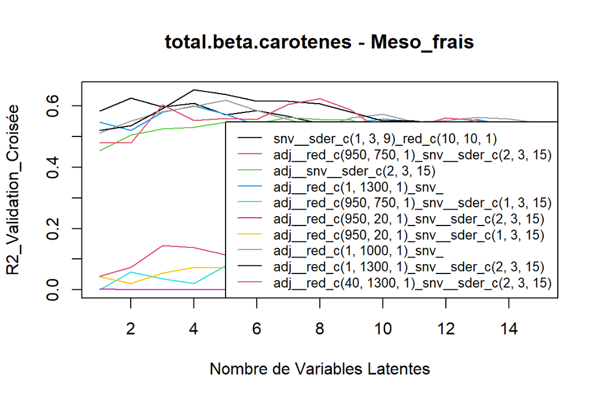

Pré : adj__red_c(1, 1300, 1)_snv__sder_c(2, 3, 15)

R2 : 0.52 0.54 0.59 0.65 0.64 0.62 0.62 0.61 0.58 0.55 0.55 0.54 0.54 0.53 0.53

SEP : 307.98 303.87 284.17 262.82 269.08 279.54 279.51 284.13 297.84 312.7 315.25 322.35 323.61 328.53 329.54

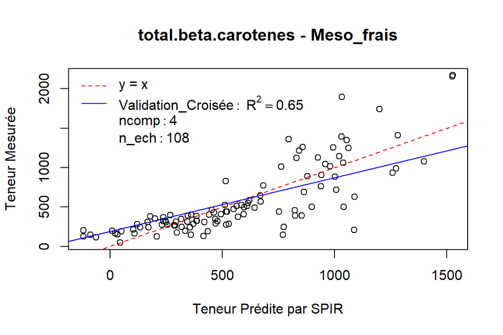

[1] “total.carotenes”

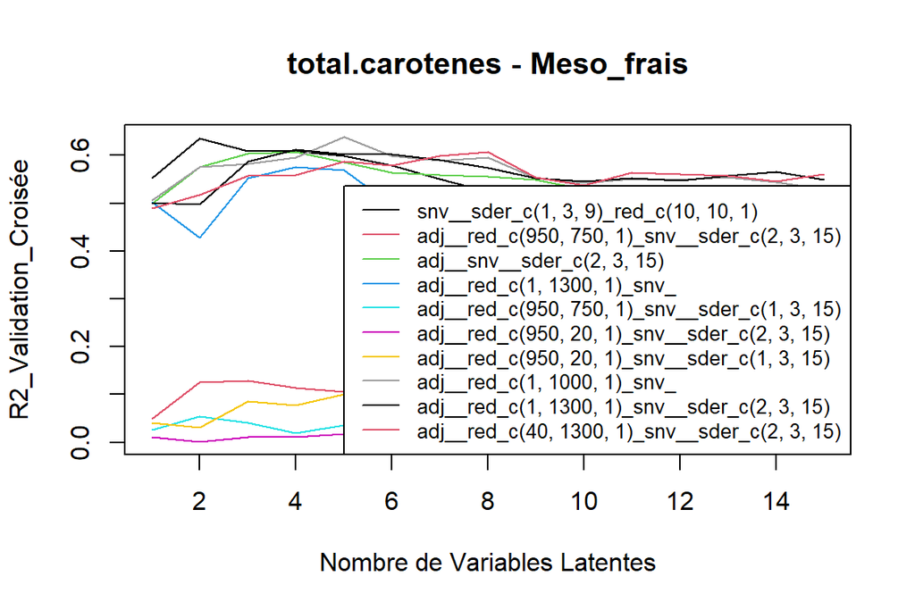

Pré : adj__red_c(1, 1000, 1)*snv*

R2 : 0.51 0.58 0.58 0.6 0.64 0.6 0.59 0.6 0.55 0.54 0.55 0.55 0.55 0.54 0.53

SEP : 531.01 493.76 491.56 484.56 456.33 486.69 497.22 494.12 531.41 545.53 540.84 547.56 545.01 552.16 566.94

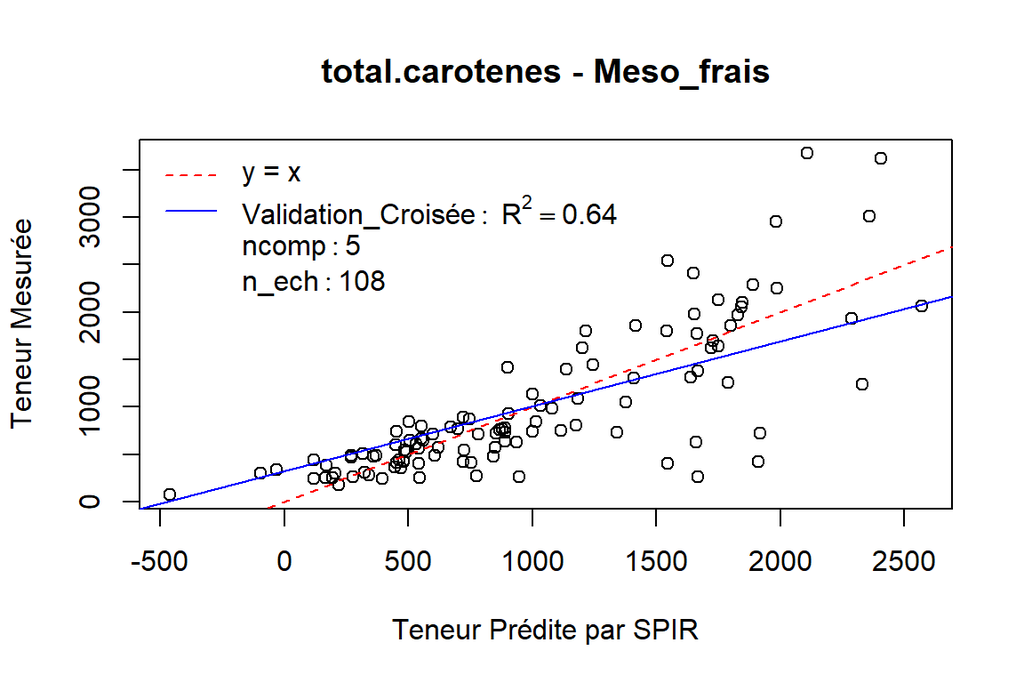